# DaliScope WorkedExample1 - HTML example output

# Which proteins have the active site's Signature Motif?

We search the full data set for matches to the HxD...H signature motif. This motif would be totally uninformative if applied to a sequence database - the distinction here is that our search space is anchored to specific positions in the structural alignment. Thus, what we identify rae targets that have a similar fold to the query **and** carry the signature motif.

```
--- Frequent Motifs (Top 10 Raw) ---
sequ_pileup
HDH    713
HHH     78
HGH     47
HMH     34
HPH     33
HNH     32
HSH     21
HFH     20
HQH     20
HLH     20
Name: count, dtype: int64

--- Selected Groups (Top-4 + 'other') ---
motif
HDH      713
other    304
HHH       78
HGH       47
HMH       34
Name: count, dtype: int64
```

Pattern [(1523, ['H']), (1525, ['D']), (1652, ['H'])]

```
[dom_5_FOLD] Pattern 1: 713 matches
Pattern definition: [(1523, ['H']), (1525, ['D']), (1652, ['H'])]
```

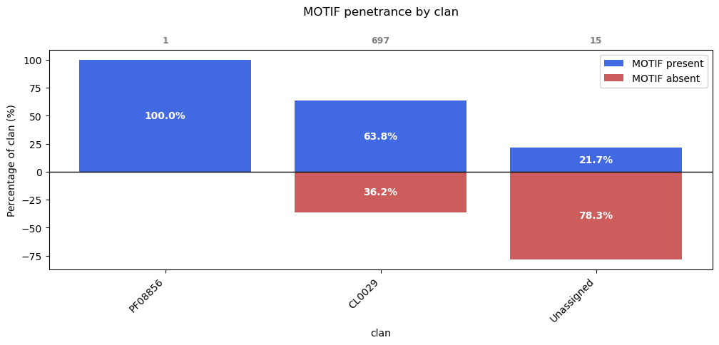

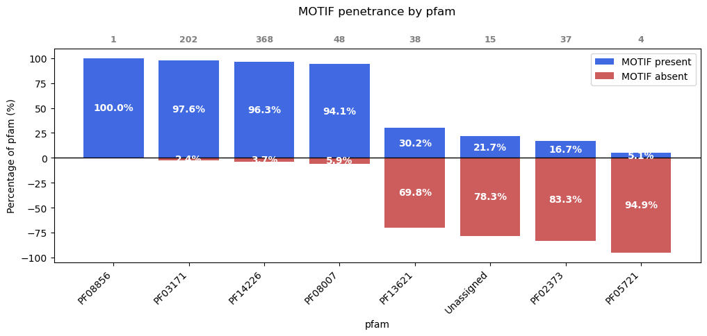

Pattern [(1523, ['H']), (1525, ['D', 'H']), (1652, ['H'])]

```
[dom_5_FOLD] Pattern 2: 791 matches
Pattern definition: [(1523, ['H']), (1525, ['D', 'H']), (1652, ['H'])]
```

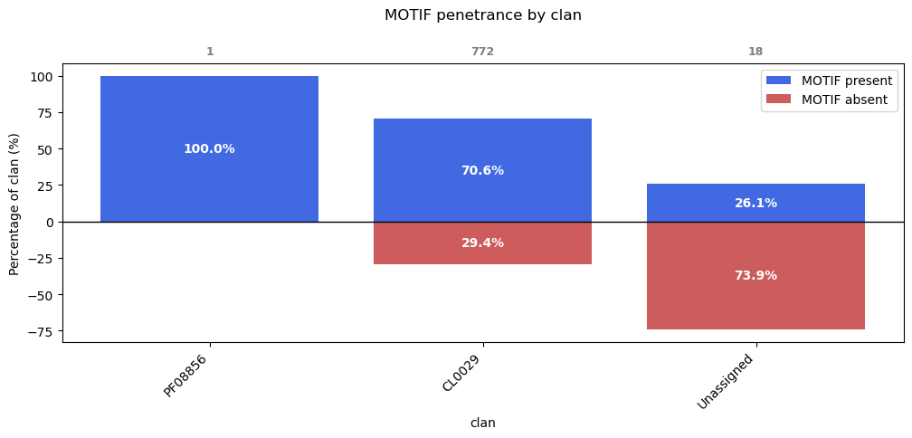

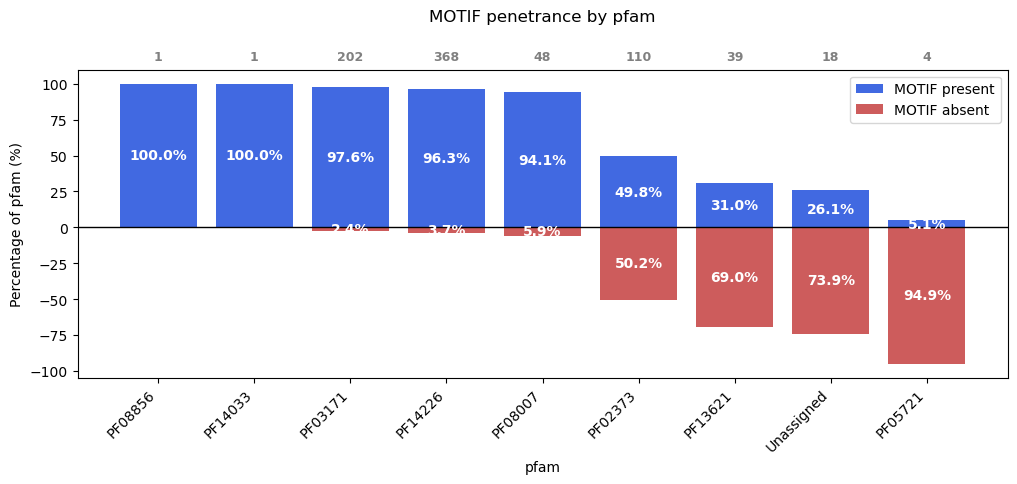

Pattern [(1523, ['H']), (1652, ['H'])]

```
[dom_5_FOLD] Pattern 3: 1107 matches
Pattern definition: [(1523, ['H']), (1652, ['H'])]
```

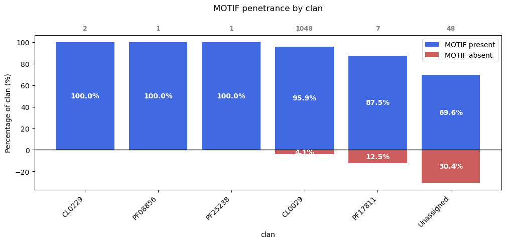

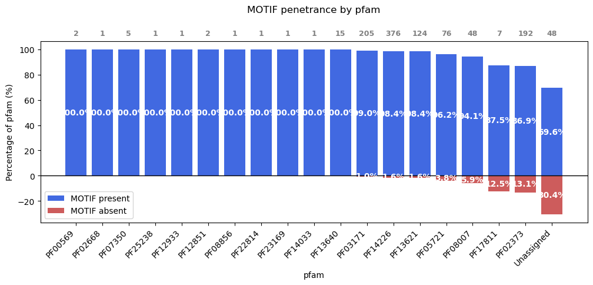

```python
import daliscope.optics.histograms

# define search population. We use a domain population for accurate Pfam annotations.
view_name = 'dom_5_FOLD'
parent_df = project.views[view_name]

daliscope.optics.histograms.set_motif(parent_df, [1523, 1525, 1652], k=4, verbose=True)

# Define all 3 patterns in the list
patterns = [
    [(1523, ["H"]), (1525, ["D"]), (1652, ["H"])],
    [(1523, ["H"]), (1525, ["D", "H"]), (1652, ["H"])],
    [(1523, ["H"]), (1652, ["H"])],
]

view = project.views[view_name]

# Loop over each pattern one by one
for i, pattern in enumerate(patterns, start=1):
    show_heading(f"Pattern {pattern}")
    # Pass a single pattern wrapped in a list: [pattern]
    hits = daliscope.optics.histograms.find_pattern_targets(view, [pattern])

    print(f"\n[{view_name}] Pattern {i}: {len(hits)} matches")
    print(f"Pattern definition: {pattern}\n")

    for category in ['clan', 'pfam']:
        # plot penetrance per category for this pattern
        daliscope.optics.histograms.draw_diverging_percentage_plot(
            view,
            hits=hits,
            grouping_col=category,
            yscale='linear',
        )
```

> The HxD...H motif is found in 697 CUPIN domains and 15 unassigned domains. Within the CUPIN superfamily, four families show almost 100% penetrance while three smaller families show partial penetrance.

> Though HxD...H was suggested by the sequence logos, enumeration of residues occurring at the important positions shows that the second position is wobbly. If only the first and last histidine are required, we recall 96% of the known CUPIN superfamily members.

```python
# 1. Get hits for the specified pattern
hits = daliscope.optics.histograms.find_pattern_targets(view, [patterns[1]])

# 2. Filter for hits where pfam is 'Unassigned'
df = project.views[view_name]
unassigned_hits_df = df[
    (df['target_id'].isin(hits)) &
    (df['pfam'] == 'Unassigned')
]

# 3. Verify sequence context
tmp = list(unassigned_hits_df['sequ_pileup'])
for row in tmp:
    print(row[1500:1540],' ... ',row[1620:1660])

# 4. Print target_id and description
print(f"\nFound {len(unassigned_hits_df)} hits with 'Unassigned' Pfam:\n")
with pd.option_context('display.max_colwidth', None):
    display(unassigned_hits_df[['target_id', 'z_score', 'description']]) #.to_string(index=False))
```

```
PIFWVRPGEREIC..FKDRTPSHADCTGAVG.ILKAIRS.  ...  KLNQI.RRSNIEYVHISLKENCVYFLPRKVIHQFRTISAC
PILWSRHGERQIT..IHDRTNCHAHTTAAVG.LLKA....  ...  ELNQL.HSEGFRYVRLPLRDNDIYFIPRNVVHQFKSVSAV
EWVLLSQ.........GHNTSPHSHGLGTWITVQ......  ...  PHGF....RGGHWCYMVLEPGQTVFFNSGTVHFVFRREAT
EWALLSE.........GHNTAPHSHGFATWITVQ......  ...  Y.......TGGRWRYVILKPGQSVFFGPGTIHFVFRGCQT
SFVLLAS.........GSYSNVHVDINGTWVSCL......  ...  KP......EPGRVKHIVLLAGEMLIMGSLTIHAPLTLEDC
GRLIHYHS.....IHSNLWQQWHYDGIFTVLTTPLFILP.  ...  ........NKKRAIMVNAPPESFIIQVRSALHCV.ENLSR
LAPTGLNCY...NEEGTIFAGYHYDNFLTIHGR.......  ...  .........NGEKVAVKVPVGCLLIQCIAGMHE...SLWR
LAPTGS.....FGNLDQIFAGFHYDNLLTIHGK.......  ...  .........DGTRVPVKVPNGCLLLQILAGFHE..KSLWR
GRLLY.......GNSLSSWCGWHTDGSLTGLTCSMFT...  ...  .......TRNNQIVKVVYGKDDIAYQICATPHCVQSGIER
GRLLY.......GNSLSSWCGWHTDGSLTGLTCGMFT...  ...  .......TRNNQIIKVVYGKDDIAYQICATPHCVQSGIER
GRLLYYF........ISSWCGWHTDGSLTGLTRAIFS...  ...  .......TRSGQIVKVVYGEDEIAYQICATPHCVRRGLER
GRLLYYYPRQ.....VSSWCGWHTDGSLTGLTCALFTK..  ...  .......TRDDKVVKVTFEENELAYQVCATPHCVKSNVDR
LAPTGS.....HGSEGTVFAGFHYDNFLTIHGR.......  ...  ........RNGKKMEVK..VGCLLIQCLAGMHEVV.SLWR
GRLLYYFPR......VSSWCGWHTDGSLTGLTCGLFTK..  ...  .......TRDNQVVKVVFDEDQLAYQICATPHCVQSNVDR
ARLLHYFP.........SWCTTHLDGCLTGLTSAMFVDE.  ...  .......SRAGQVHKVSIPRDALAFQTKAVPHFVKMSIAR
ARLLHY.YPQTA......WCATHLDGCLTGLTSAMFVDE.  ...  .......SRTGDIVQVKIPRDCIAFQTKAVPHFVRSRIAR
AHINV............SVGRWHTDYPWVCVCMLSDP...  ...  .......KGDGTIAKIGPQVGWAVMQGGCIEHIAL.TGER
ARLLH............DWCATHLDGCLTGL...MFIDE.  ...  .......SRTGQTVQVKIPRDCIAFQTKAVPHFV..RIAR

Found 18 hits with 'Unassigned' Pfam:
```

|  | target_id | z_score | description |
| --- | --- | --- | --- |
| 73 | i5geA | 21.0 | STRER/AFDB:AF-A0A0K0DS03-F1 Uncharacterized protein UNCHARACTERIZED PROTEIN; |
| 74 | kc2hA | 20.9 | SCHMA/AFDB:AF-A0A3Q0KEA1-F1 Uncharacterized protein UNCHARACTERIZED PROTEIN; |
| 349 | vx5rA | 14.8 | SPOS1/AFDB:AF-U7PWI3-F1 JmjC domain-containing protein JMJC DOMAIN-CONTAINING PROTEIN; |
| 360 | wboqA | 14.4 | 9PEZI1/AFDB:AF-A0A175W0J7-F1 JmjC domain-containing protein JMJC DOMAIN-CONTAINING PROTEIN; |
| 363 | w46xA | 14.1 | 9EURO1/AFDB:AF-A0A1C1CJD8-F1 Uncharacterized protein UNCHARACTERIZED PROTEIN; |
| 1052 | haigA | 7.8 | SOYBN:AF-I1JF77-F1 UNCHARACTERIZED PROTEIN; |
| 1084 | ajz7A | 7.7 | ARATH:AF-Q9FI36-F1 2-OXOGLUTARATE (2OG) AND FE(II)-DEPENDENT OXYGENA |
| 1087 | fxwlA | 7.7 | DICDI:AF-Q55GT3-F1 FE2OG DIOXYGENASE DOMAIN-CONTAINING PROTEIN; |
| 1090 | hl87A | 7.6 | SOYBN:AF-I1LNX0-F1 FE2OG DIOXYGENASE DOMAIN-CONTAINING PROTEIN; |
| 1097 | hsgkA | 7.6 | SOYBN:AF-K7LFI0-F1 FE2OG DIOXYGENASE DOMAIN-CONTAINING PROTEIN; |
| 1098 | ajuvA | 7.6 | ARATH:AF-F4JT13-F1 2-OXOGLUTARATE (2OG) AND FE(II)-DEPENDENT OXYGENA |
| 1099 | cl6qA | 7.6 | ORYSJ:AF-Q6I615-F1 OS05G0556000 PROTEIN; |
| 1103 | bhvqA | 7.6 | MAIZE:AF-B6TNK2-F1 2-OXOGLUTARATE (2OG) AND FE(II)-DEPENDENT OXYGENA |
| 1119 | bde5A | 7.4 | MAIZE:AF-A0A1D6MC07-F1 2-OXOGLUTARATE (2OG) AND FE(II)-DEPENDENT OXYGENA |
| 1123 | j7xvA | 7.3 | 9EURO2/AFDB:AF-A0A0D2EKU5-F1 Unplaced genomic scaffold supercont1.8, whole genome shotgun sequence UNPLACED GENOMIC SCAFFOLD SUPERCONT1.8, WHOLE GEN |
| 1133 | w27sA | 7.2 | SPOS1/AFDB:AF-U7Q287-F1 Uncharacterized protein UNCHARACTERIZED PROTEIN; |
| 1142 | w855A | 7.0 | 9EURO1/AFDB:AF-A0A1C1CZ39-F1 Uncharacterized protein UNCHARACTERIZED PROTEIN; |
| 1150 | whg7A | 6.7 | 9PEZI1/AFDB:AF-A0A175VWB9-F1 Uncharacterized protein UNCHARACTERIZED PROTEIN; |

> The unassigned hits include dioxygenase and JmjC domain annotations, which are members of the CUPIN superfamily. Half of then appear wholly uncharacterized.

# Conclusion

In this worked example, **DaliScope** successfully uncovered the full structural architecture of a query protein whose sequence-based Pfam annotations were sparse and incomplete:

- **Unmapped Domain Boundaries:** We delineated all five recurrent structural domains comprising the query protein, establishing precise boundaries that sequence profiles failed to resolve.
- **Identification of Tudor & Shadow Domains:** We identified two **SH3-like (Tudor)** domains and two previously uncharacterized **CUPIN shadow domains**.
- **Structural Co-occurrence & Function:** We demonstrated that these shadow domains reliably co-occur alongside the canonical CUPIN domain and harbor **four distinct metal-binding sites**, pointing to a potential regulatory mechanism for CUPIN activity.

Ultimately, this analysis illustrates the power of **3D structural alignment in DaliScope** to go beyond primary sequence matching—filling critical gaps in Pfam coverage, revealing hidden regulatory modules, and expanding our understanding of multidomain protein evolution.

dom_0-1724 (n=1573)

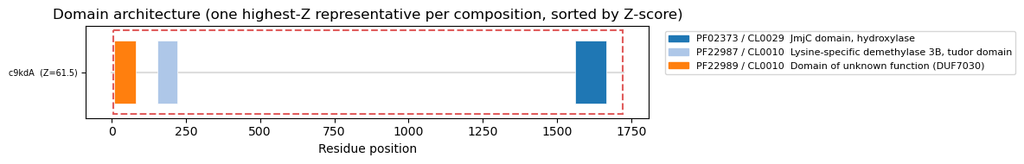

```python
# This is how the Query is annotated by Pfam
project.viz.architecture(FULL_VIEW, renderer='matplotlib', pfam_col='pfam_domains', max_targets=1)
```